# 4T1 RNA Seq - Differential Analysis

Andrew Chen

June 28, 2023

```r
library(Biobase)
library(SummarizedExperiment)
library(tidyverse)
library(ggplot2)
library(DESeq2)
library(reactable)
library(cba)
library(pheatmap)
library(vennr)

PATH <- file.path(Sys.getenv("MLAB"),"projects/brcameta/exosome/4t1_brca/")
DPATH <- file.path(Sys.getenv("CBM"),"otherStudies/RNAseq/2023-03-22-YuhanExosomeBrCa")
```

# Load Data

```r
dat <- readRDS(file.path(PATH,"data/4T1_sExp.rds"))
dat_pool <- readRDS(file.path(PATH,"data/4T1_control_IS_pool_sExp.rds"))
```

# DESeq Result Tables

> DESeq2 performs an internal normalization where geometric mean is calculated for each gene across all samples. The counts for a gene in each sample is then divided by this mean. The median of these ratios in a sample is the size factor for that sample. This procedure corrects for library size and RNA composition bias, which can arise for example when only a small number of genes are very highly expressed in one experiment condition but not in the other.

```r
dds <- DESeq2::DESeqDataSetFromMatrix(countData=round(assays(dat)$counts),
                                      colData=dat@colData,
                                      design=~condition)
```

```r
# Map EnsemblID to GeneID
ensembl_symbol <- function(ensembl_id, sExp) {
  return(unlist(rowData(sExp)[ensembl_id,"mgi_symbol"]))
}
symbol_ensembl <- function(gene_id, sExp) {
  return(rownames(sExp)[rowData(sExp)$mgi_symbol == gene_id])
}
```

```r
dds <- DESeq(dds)
```

## IR IS

Summary of Different comparisons

```r
lfcs <- seq(0,0.5,0.1)
comp_df <- data.frame(lfcs = lfcs)
for (i in seq_along(lfcs)) {
  lfc <- lfcs[i]
  dds_res <- results(dds, alpha=0.05, lfcThreshold = lfc, contrast=c("condition", "IR", "IS"))
  nPos <- sum((dds_res$padj < 0.05) & (dds_res$log2FoldChange > lfc), na.rm=TRUE)
  nNeg <- sum((dds_res$padj < 0.05) & (dds_res$log2FoldChange < -lfc), na.rm=TRUE)
  comp_df$nPos[i] = nPos
  comp_df$nNeg[i] = nNeg
}

comp_df
```

| lfcs | nPos | nNeg |
| --- | --- | --- |
| 0.0 | 182 | 248 |
| 0.1 | 24 | 49 |
| 0.2 | 4 | 16 |
| 0.3 | 1 | 9 |
| 0.4 | 0 | 4 |
| 0.5 | 0 | 1 |

```r
dds_IR_IS_res <- results(dds, alpha=0.05, lfcThreshold = 0.1, contrast=c("condition", "IR", "IS"))
dds_IR_IS_res_df <- dds_IR_IS_res[which(with(dds_IR_IS_res, padj<0.05 & (log2FoldChange < -0.1 | log2FoldChange > 0.1))),] %>% as.data.frame
dds_IR_IS_res_df_symbol <- unlist(lapply(rownames(dds_IR_IS_res_df), ensembl_symbol, sExp=dat))
dds_IR_IS_res_df <- dds_IR_IS_res_df[dds_IR_IS_res_df_symbol != "",]
rownames(dds_IR_IS_res_df) <- dds_IR_IS_res_df_symbol[dds_IR_IS_res_df_symbol != ""]
write.csv(dds_IR_IS_res_df[order(dds_IR_IS_res_df$log2FoldChange),], file=file.path(PATH, "data/dds_IR_IS_diffanal.csv"))
```

Table of Results

```r
reactable(dds_IR_IS_res_df, searchable = TRUE)
```

|  | baseMean | log2FoldChange | lfcSE | stat | pvalue | padj |
| --- | --- | --- | --- | --- | --- | --- |
| Ccnd2 | 1378.3459212090304 | -0.4962164593910787 | 0.06297050113536214 | -6.292096334748347 | 3.1320699629486367e-10 | 3.4882717378257956e-07 |
| Cyp51 | 898.3518076851396 | 0.46849946482548377 | 0.07348837371001056 | 5.01439134140598 | 5.320160719893284e-07 | 0.0002506818806900485 |
| Dusp3 | 562.9427291116441 | -0.44354002585346824 | 0.08078742437045786 | -4.252394831627941 | 2.1149654756957755e-05 | 0.0063196200104265726 |
| Podnl1 | 704.7532051285718 | -0.7549366842538339 | 0.08587453935134509 | -7.6266689661558615 | 2.408971255211921e-14 | 5.902461369520249e-11 |
| Igf2bp1 | 483.0634053725851 | -0.4306843689391127 | 0.09099007155352247 | -3.6342906791165284 | 0.00027874645697860433 | 0.04742948395062335 |
| Csf1 | 4715.214603021761 | -0.2894236331996626 | 0.04533334475221306 | -4.178461444551042 | 2.9348773610309782e-05 | 0.007650038840423513 |
| Wfdc2 | 3291.7302786611444 | 0.3210480991486408 | 0.06107734164538898 | 3.61915062433515 | 0.0002955715687494553 | 0.04960338751711749 |
| Mmp9 | 4928.805055276304 | -0.3134809218094171 | 0.04793739205419832 | -4.4533278232586 | 8.454951223358182e-06 | 0.00287726687326003 |
| Ccn2 | 5140.073371608169 | -0.6583222786201957 | 0.058952752556970536 | -9.47067362258694 | 2.780447734945532e-21 | 3.406326520081771e-17 |
| Havcr2 | 67.5855423718271 | -0.8390774645539429 | 0.2028575126374873 | -3.6433329727092603 | 0.00026913031892589065 | 0.04643824700226882 |

[output cut: 63 more lines]

## TGFB IS

Summary of Different comparisons

```r
lfcs <- seq(0,1.0,0.2)
comp_df <- data.frame(lfcs = lfcs)
for (i in seq_along(lfcs)) {
  lfc <- lfcs[i]
  dds_res <- results(dds, alpha=0.05, lfcThreshold = lfc, contrast=c("condition", "TGFB", "IS"))
  nPos <- sum((dds_res$padj < 0.05) & (dds_res$log2FoldChange > lfc), na.rm=TRUE)
  nNeg <- sum((dds_res$padj < 0.05) & (dds_res$log2FoldChange < -lfc), na.rm=TRUE)
  comp_df$nPos[i] = nPos
  comp_df$nNeg[i] = nNeg
}

comp_df
```

| lfcs | nPos | nNeg |
| --- | --- | --- |
| 0.0 | 2328 | 2165 |
| 0.2 | 770 | 974 |
| 0.4 | 406 | 544 |
| 0.6 | 260 | 337 |
| 0.8 | 196 | 222 |
| 1.0 | 137 | 161 |

```r
dds_TGFB_IS_res <- results(dds, alpha=0.05, lfcThreshold = 1, contrast=c("condition", "TGFB", "IS"))
dds_TGFB_IS_res_df <- dds_TGFB_IS_res[which(with(dds_TGFB_IS_res, padj<0.05 & (log2FoldChange < -1 | log2FoldChange > 1))),] %>% as.data.frame
dds_TGFB_IS_res_df_symbol <- unlist(lapply(rownames(dds_TGFB_IS_res_df), ensembl_symbol, sExp=dat))
dds_TGFB_IS_res_df <- dds_TGFB_IS_res_df[dds_TGFB_IS_res_df_symbol != "",]
rownames(dds_TGFB_IS_res_df) <- dds_TGFB_IS_res_df_symbol[dds_TGFB_IS_res_df_symbol != ""]
write.csv(dds_TGFB_IS_res_df[order(dds_TGFB_IS_res_df$log2FoldChange),], file=file.path(PATH, "data/dds_TGFB_IS_diffanal.csv"))
```

Table of Results

```r
reactable(dds_TGFB_IS_res_df, searchable = TRUE)
```

|  | baseMean | log2FoldChange | lfcSE | stat | pvalue | padj |
| --- | --- | --- | --- | --- | --- | --- |
| H19 | 88.3345933528777 | 2.4129745842117694 | 0.2058297694899972 | 6.864772708597122 | 6.659720239123797e-12 | 7.062471153726847e-10 |
| Wnt9a | 54.874483156777345 | 3.4438188636928064 | 0.27598237207775256 | 8.854981734138834 | 8.369751704880829e-19 | 1.3856463261688518e-16 |
| Pdgfb | 2411.7465601385497 | 2.9000991530747213 | 0.054763522607508934 | 34.69643774913391 | 8.91567514354353e-264 | 3.640864539451726e-260 |
| Itgb7 | 28.850899037823503 | -3.3516717526794904 | 0.48331462407868253 | -4.865716110209493 | 1.1404311844440095e-06 | 7.392287005620932e-05 |
| Cyp51 | 898.3518076851396 | 1.3825651583077858 | 0.07055529301344401 | 5.422203522489654 | 5.8868801234428043e-08 | 4.4512138480476745e-06 |
| Col1a1 | 34.52897717768806 | 3.687988938578279 | 0.35852863212063973 | 7.497278314089596 | 6.515653977754018e-14 | 8.062957260753988e-12 |
| Ier3 | 1531.243897427022 | -1.4966251045124652 | 0.06400120000546845 | -7.759621764436169 | 8.518304682876358e-15 | 1.1467884689002007e-12 |
| Cp | 242.9954588670787 | -1.4401701228600323 | 0.12568922936677923 | -3.502051250354576 | 0.0004616908002268194 | 0.02020062140563844 |
| Nqo1 | 124.51324602111187 | -1.648678350000475 | 0.17900986650225026 | -3.6237016577648844 | 0.0002904165793128414 | 0.012937794593314981 |
| Aqp1 | 183.64279785438669 | -2.377058327558724 | 0.17455630712979403 | -7.8889061655892565 | 3.0484661937289434e-15 | 4.292730958548654e-13 |

[output cut: 288 more lines]

## IR Control

```r
lfcs <- seq(0,0.5,0.1)
comp_df <- data.frame(lfcs = lfcs)
for (i in seq_along(lfcs)) {
  lfc <- lfcs[i]
  dds_res <- results(dds, alpha=0.05, lfcThreshold = lfc, contrast=c("condition", "IR", "C"))
  nPos <- sum((dds_res$padj < 0.05) & (dds_res$log2FoldChange > lfc), na.rm=TRUE)
  nNeg <- sum((dds_res$padj < 0.05) & (dds_res$log2FoldChange < -lfc), na.rm=TRUE)
  comp_df$nPos[i] = nPos
  comp_df$nNeg[i] = nNeg
}

comp_df
```

| lfcs | nPos | nNeg |
| --- | --- | --- |
| 0.0 | 493 | 568 |
| 0.1 | 218 | 190 |
| 0.2 | 129 | 102 |
| 0.3 | 92 | 59 |
| 0.4 | 59 | 43 |
| 0.5 | 50 | 31 |

```r
dds_IR_C_res <- results(dds, alpha=0.05, lfcThreshold = 0.5, contrast=c("condition", "IR", "C"))
summary(dds_IR_C_res)
```

```
##
## out of 12257 with nonzero total read count
## adjusted p-value < 0.05
## LFC > 0.50 (up)    : 50, 0.41%
## LFC < -0.50 (down) : 31, 0.25%
## outliers [1]       : 6, 0.049%
## low counts [2]     : 0, 0%
## (mean count < 4)
## [1] see 'cooksCutoff' argument of ?results
## [2] see 'independentFiltering' argument of ?results
```

```r
dds_IR_C_res_df <- dds_IR_C_res[which(with(dds_IR_C_res, padj<0.05 & (log2FoldChange < -0.5 | log2FoldChange > 0.5))),] %>% as.data.frame
dds_IR_C_res_df_symbol <- unlist(lapply(rownames(dds_IR_C_res_df), ensembl_symbol, sExp=dat))
dds_IR_C_res_df <- dds_IR_C_res_df[dds_IR_C_res_df_symbol != "",]
rownames(dds_IR_C_res_df) <- dds_IR_C_res_df_symbol[dds_IR_C_res_df_symbol != ""]
write.csv(dds_IR_C_res_df[order(dds_IR_C_res_df$log2FoldChange),], file=file.path(PATH, "data/dds_IR_C_diffanal.csv"))
```

Table of Results

```r
reactable(dds_IR_C_res_df, searchable = TRUE)
```

|  | baseMean | log2FoldChange | lfcSE | stat | pvalue | padj |
| --- | --- | --- | --- | --- | --- | --- |
| Pdgfb | 2411.7465601385497 | -1.2033197566421996 | 0.05903815177325727 | -11.912970435513955 | 1.013029453625437e-32 | 9.546633720280944e-30 |
| Cyp51 | 898.3518076851396 | -1.0942034692831133 | 0.06714193013789585 | -8.849961090822685 | 8.754981370773802e-19 | 5.645119830176307e-16 |
| Angptl4 | 44.16456339901695 | 2.0941002295279705 | 0.3125569339506318 | 5.100191537519234 | 3.393099376583206e-07 | 7.994011627407856e-05 |
| Ier3 | 1531.243897427022 | 0.8536770846837839 | 0.060369442537194444 | 5.8585448170384975 | 4.669406086487903e-09 | 1.3303463712921698e-06 |
| Cp | 242.9954588670787 | 1.43597486922048 | 0.12342034319634908 | 7.5836352823248925 | 3.360048440055689e-14 | 1.2473925284582498e-11 |
| Pou2f2 | 12.256576502385268 | 2.877545557383438 | 0.6450424895253084 | 3.6858743353993497 | 0.0002279188004564488 | 0.037732881410702086 |
| Mgst1 | 39.175786814151024 | 1.9528715245886707 | 0.3108771410224825 | 4.6734588455431005 | 2.9616907410783265e-06 | 0.0006149775130330606 |
| Ehf | 6.616711353898488 | 6.261646500392372 | 1.2924118741268542 | 4.458057540120409 | 8.270570368461548e-06 | 0.0016342380255487488 |
| Gadd45b | 655.62794029781 | -0.8303264957763241 | 0.09110935042765048 | -3.6256047730099326 | 0.0002882859818522023 | 0.04360236498359667 |
| Slpi | 237.8132693676707 | 2.3681170971483985 | 0.13964821757464646 | 13.37730713354669 | 8.206713428446294e-41 | 1.0054044621189555e-37 |

[output cut: 71 more lines]

## TGFB Control

```r
lfcs <- seq(0,1,0.2)
comp_df <- data.frame(lfcs = lfcs)
for (i in seq_along(lfcs)) {
  lfc <- lfcs[i]
  dds_res <- results(dds, alpha=0.05, lfcThreshold = lfc, contrast=c("condition", "TGFB", "C"))
  nPos <- sum((dds_res$padj < 0.05) & (dds_res$log2FoldChange > lfc), na.rm=TRUE)
  nNeg <- sum((dds_res$padj < 0.05) & (dds_res$log2FoldChange < -lfc), na.rm=TRUE)
  comp_df$nPos[i] = nPos
  comp_df$nNeg[i] = nNeg
}

comp_df
```

| lfcs | nPos | nNeg |
| --- | --- | --- |
| 0.0 | 1604 | 1571 |
| 0.2 | 643 | 593 |
| 0.4 | 406 | 308 |
| 0.6 | 276 | 168 |
| 0.8 | 198 | 104 |
| 1.0 | 144 | 65 |

```r
dds_TGFB_C_res <- results(dds, alpha=0.05, lfcThreshold = 1, contrast=c("condition", "TGFB", "C"))
summary(dds_TGFB_C_res)
```

```
##
## out of 12257 with nonzero total read count
## adjusted p-value < 0.05
## LFC > 1.00 (up)    : 144, 1.2%
## LFC < -1.00 (down) : 65, 0.53%
## outliers [1]       : 6, 0.049%
## low counts [2]     : 0, 0%
## (mean count < 4)
## [1] see 'cooksCutoff' argument of ?results
## [2] see 'independentFiltering' argument of ?results
```

```r
dds_TGFB_C_res_df <- dds_TGFB_C_res[which(with(dds_res, padj<0.05 & (log2FoldChange < -1 | log2FoldChange > 1))),] %>% as.data.frame
dds_TGFB_C_res_df_symbol <- unlist(lapply(rownames(dds_TGFB_C_res_df), ensembl_symbol, sExp=dat))
dds_TGFB_C_res_df <- dds_TGFB_C_res_df[dds_TGFB_C_res_df_symbol != "",]
rownames(dds_TGFB_C_res_df) <- dds_TGFB_C_res_df_symbol[dds_TGFB_C_res_df_symbol != ""]
write.csv(dds_TGFB_C_res_df[order(dds_TGFB_C_res_df$log2FoldChange),], file=file.path(PATH, "data/dds_TGFB_C_diffanal.csv"))
```

Table of Results

```r
reactable(dds_TGFB_C_res_df, searchable = TRUE)
```

|  | baseMean | log2FoldChange | lfcSE | stat | pvalue | padj |
| --- | --- | --- | --- | --- | --- | --- |
| H19 | 88.3345933528777 | 2.569810204981566 | 0.21401147230668396 | 7.335168475136638 | 2.214427440478646e-13 | 3.308408606500475e-11 |
| Wnt9a | 54.874483156777345 | 2.7573329091243566 | 0.2516240737678635 | 6.983961760135832 | 2.869702040195356e-12 | 4.0410022637279665e-10 |
| Pdgfb | 2411.7465601385497 | 1.9589345906940587 | 0.05176168597773965 | 18.525953561606418 | 1.2752377758562622e-76 | 1.5622937992015068e-73 |
| Col1a1 | 34.52897717768806 | 4.9972913570707655 | 0.4983488392708168 | 8.021070868589954 | 1.0482722360715458e-15 | 1.9167736065839562e-13 |
| Aqp1 | 183.64279785438669 | -2.4439092715527875 | 0.17501482006719626 | -8.250211444941657 | 1.5811451565558253e-16 | 3.124291824671841e-14 |
| Ccn4 | 991.7922955878437 | 4.347704361869557 | 0.09515842615895358 | 35.18032503267255 | 3.9981862239768604e-271 | 1.224544485748513e-267 |
| Adamts4 | 118.53893039378389 | 2.273194095896559 | 0.1811617761376223 | 7.027940016051496 | 2.096049635962029e-12 | 2.985895824438467e-10 |
| Crlf1 | 69.47025865749434 | 2.2714523224958363 | 0.22580463874164827 | 5.6307626343786215 | 1.7941450651636184e-08 | 1.8948337235620249e-06 |
| Eps8 | 1625.7318198597407 | -1.6763321928221613 | 0.06109017876437277 | -11.071046222189024 | 1.733646716290006e-28 | 5.445873313145863e-26 |
| Wnt11 | 22.88330793268261 | 3.5636576457619658 | 0.4476881651299413 | 5.726436045093721 | 1.0256240133110468e-08 | 1.1021859462345293e-06 |

[output cut: 199 more lines]

## IS Control

```r
lfcs <- seq(0,0.5,0.1)
comp_df <- data.frame(lfcs = lfcs)
for (i in seq_along(lfcs)) {
  lfc <- lfcs[i]
  dds_res <- results(dds, alpha=0.05, lfcThreshold = lfc, contrast=c("condition", "IS", "C"))
  nPos <- sum((dds_res$padj < 0.05) & (dds_res$log2FoldChange > lfc), na.rm=TRUE)
  nNeg <- sum((dds_res$padj < 0.05) & (dds_res$log2FoldChange < -lfc), na.rm=TRUE)
  comp_df$nPos[i] = nPos
  comp_df$nNeg[i] = nNeg
}

comp_df
```

| lfcs | nPos | nNeg |
| --- | --- | --- |
| 0.0 | 786 | 709 |
| 0.1 | 357 | 189 |
| 0.2 | 209 | 90 |
| 0.3 | 114 | 54 |
| 0.4 | 75 | 41 |
| 0.5 | 55 | 30 |

```r
dds_IS_C_res <- results(dds, alpha=0.05, lfcThreshold = 0.5, contrast=c("condition", "IS", "C"))
summary(dds_IS_C_res)
```

```
##
## out of 12257 with nonzero total read count
## adjusted p-value < 0.05
## LFC > 0.50 (up)    : 55, 0.45%
## LFC < -0.50 (down) : 30, 0.24%
## outliers [1]       : 6, 0.049%
## low counts [2]     : 0, 0%
## (mean count < 4)
## [1] see 'cooksCutoff' argument of ?results
## [2] see 'independentFiltering' argument of ?results
```

```r
dds_IS_C_res_df <- as.data.frame(dds_IS_C_res[which(dds_IS_C_res$padj < 0.05, dds_IS_C_res$log2FoldChange > 0.5),])
dds_IS_C_res_df_symbol <- unlist(lapply(rownames(dds_IS_C_res_df), ensembl_symbol, sExp=dat_pool))
dds_IS_C_res_df <- dds_IS_C_res_df[dds_IS_C_res_df_symbol != "",]
rownames(dds_IS_C_res_df) <- dds_IS_C_res_df_symbol[dds_IS_C_res_df_symbol != ""]
write.csv(dds_IS_C_res_df[order(dds_IS_C_res_df$log2FoldChange),], file=file.path(PATH,"data/dds_IS_Control_pool_diffanal.csv"))
```

Table of Results

```r
reactable(dds_IS_C_res_df, searchable = TRUE)
```

|  | baseMean | log2FoldChange | lfcSE | stat | pvalue | padj |
| --- | --- | --- | --- | --- | --- | --- |
| Pdgfb | 2411.7465601385497 | -0.941164562380663 | 0.05758412562702121 | -7.661218392689245 | 1.8417735428284948e-14 | 7.521189224397296e-12 |
| Cyp51 | 898.3518076851396 | -1.562702934108597 | 0.06984967554548942 | -15.214142740240998 | 2.8492729831825396e-52 | 3.490644331696929e-49 |
| Angptl4 | 44.16456339901695 | 1.9295482985286638 | 0.3141342861013559 | 4.550755399133407 | 5.345365972171842e-06 | 0.0010735422709029056 |
| Ier3 | 1531.243897427022 | 0.7682739870029961 | 0.06048702054277457 | 4.435232296047396 | 9.197305949831466e-06 | 0.0017072150786573528 |
| Cp | 242.9954588670787 | 1.3715268937619134 | 0.12361888962260055 | 7.050111001826836 | 1.787751189211453e-12 | 6.441688182067503e-10 |
| Mvd | 203.50055775769397 | -1.0908417937541484 | 0.1229909254794137 | -4.80394623791203 | 1.5556861706332702e-06 | 0.00035959832597034326 |
| Pou2f2 | 12.256576502385268 | 2.818010790204679 | 0.6456050606253048 | 3.590447057461965 | 0.00033011127923111475 | 0.047578744492475136 |
| Mgst1 | 39.175786814151024 | 2.0711093189737313 | 0.30923495132960005 | 5.080633066277021 | 3.761791203024145e-07 | 9.601188339218499e-05 |
| Ehf | 6.616711353898488 | 5.907829859114179 | 1.2968865267935663 | 4.169855841192634 | 3.0479237375419333e-05 | 0.005334301958375175 |
| Slpi | 237.8132693676707 | 1.9630973811967276 | 0.14116440184021065 | 10.364492479151105 | 3.5966264340426367e-25 | 2.4479039135253524e-22 |

[output cut: 75 more lines]

## TGFB IR

```r
lfcs <- seq(0,1,0.2)
comp_df <- data.frame(lfcs = lfcs)
for (i in seq_along(lfcs)) {
  lfc <- lfcs[i]
  dds_res <- results(dds, alpha=0.05, lfcThreshold = lfc, contrast=c("condition", "TGFB", "IR"))
  nPos <- sum((dds_res$padj < 0.05) & (dds_res$log2FoldChange > lfc), na.rm=TRUE)
  nNeg <- sum((dds_res$padj < 0.05) & (dds_res$log2FoldChange < -lfc), na.rm=TRUE)
  comp_df$nPos[i] = nPos
  comp_df$nNeg[i] = nNeg
}

comp_df
```

| lfcs | nPos | nNeg |
| --- | --- | --- |
| 0.0 | 2149 | 2040 |
| 0.2 | 812 | 861 |
| 0.4 | 460 | 479 |
| 0.6 | 298 | 295 |
| 0.8 | 211 | 204 |
| 1.0 | 157 | 142 |

```r
dds_TGFB_IR_res <- results(dds, alpha=0.05, lfcThreshold = 1, contrast=c("condition", "TGFB", "IR"))
summary(dds_TGFB_IR_res)
```

```
##
## out of 12257 with nonzero total read count
## adjusted p-value < 0.05
## LFC > 1.00 (up)    : 157, 1.3%
## LFC < -1.00 (down) : 142, 1.2%
## outliers [1]       : 6, 0.049%
## low counts [2]     : 0, 0%
## (mean count < 4)
## [1] see 'cooksCutoff' argument of ?results
## [2] see 'independentFiltering' argument of ?results
```

```r
dds_TGFB_IR_res_df <- as.data.frame(dds_TGFB_IR_res[which(dds_TGFB_IR_res$padj < 0.05, dds_TGFB_IR_res$log2FoldChange > 0.5),])
dds_TGFB_IR_res_df_symbol <- unlist(lapply(rownames(dds_TGFB_IR_res_df), ensembl_symbol, sExp=dat_pool))
dds_TGFB_IR_res_df <- dds_TGFB_IR_res_df[dds_TGFB_IR_res_df_symbol != "",]
rownames(dds_TGFB_IR_res_df) <- dds_TGFB_IR_res_df_symbol[dds_TGFB_IR_res_df_symbol != ""]
write.csv(dds_TGFB_IR_res_df[order(dds_TGFB_IR_res_df$log2FoldChange),], file=file.path(PATH,"data/dds_TGFB_IR_diffanal.csv"))
```

Table of Results

```r
reactable(dds_TGFB_IR_res_df, searchable = TRUE)
```

|  | baseMean | log2FoldChange | lfcSE | stat | pvalue | padj |
| --- | --- | --- | --- | --- | --- | --- |
| H19 | 88.3345933528777 | 2.7582777671815473 | 0.2163312310721607 | 8.127711188381515 | 4.374720148071836e-16 | 5.30640559742852e-14 |
| Wnt9a | 54.874483156777345 | 3.7890669106397987 | 0.2985727480350632 | 9.341331146244674 | 9.513047188010453e-21 | 1.4568042637539506e-18 |
| Pdgfb | 2411.7465601385497 | 3.1622543473362583 | 0.05629045434150334 | 38.41245150053822 | 0 | 0 |
| Col18a1 | 2514.7923667618284 | -1.2694915690820558 | 0.05202669091680374 | -5.179871414712917 | 2.220389012827586e-07 | 1.4241877380183642e-05 |
| Col1a1 | 34.52897717768806 | 4.987947721885594 | 0.48331343219402495 | 8.251266065133159 | 1.5672518256258124e-16 | 1.9592247056879415e-14 |
| Ier3 | 1531.243897427022 | -1.5820282021932528 | 0.0638900895298926 | -9.109835445150475 | 8.250701749886845e-20 | 1.1753412457891132e-17 |
| Cp | 242.9954588670787 | -1.5046180983185988 | 0.12549395850062653 | -4.021054912504649 | 5.79380957654834e-05 | 0.002805532060169712 |
| Cacna1b | 11.655949890732506 | 3.113400207396435 | 0.6237155880186303 | 3.3884037019342674 | 0.0007030070964127187 | 0.03000884995871853 |
| Aqp1 | 183.64279785438669 | -2.586494432134196 | 0.1735450322642404 | -9.141687384739386 | 6.148535431694623e-20 | 8.967346139725098e-18 |
| Ccn4 | 991.7922955878437 | 4.072918225640141 | 0.0896866386914814 | 34.262831905328305 | 2.8090357839882872e-257 | 5.735582898273418e-254 |

[output cut: 289 more lines]

# Signature Comparison

```r
# Preparing Signatures
ir_c_up_signatures <- dds_IR_C_res_df %>% dplyr::filter(log2FoldChange > 0) %>% rownames
is_c_up_signatures <- dds_IS_C_res_df %>% dplyr::filter(log2FoldChange > 0) %>% rownames
tgfb_c_up_signatures <- dds_TGFB_C_res_df %>% dplyr::filter(log2FoldChange > 0) %>% rownames
ir_is_up_signatures <- dds_IR_IS_res_df %>% dplyr::filter(log2FoldChange > 0) %>% rownames
tgfb_is_up_signatures <- dds_TGFB_IS_res_df %>% dplyr::filter(log2FoldChange > 0) %>% rownames
tgfb_ir_up_signatures <- dds_TGFB_IR_res_df %>% dplyr::filter(log2FoldChange > 0) %>% rownames

ir_c_down_signatures <- dds_IR_C_res_df %>% dplyr::filter(log2FoldChange < -0) %>% rownames
is_c_down_signatures <- dds_IS_C_res_df %>% dplyr::filter(log2FoldChange < -0) %>% rownames
tgfb_c_down_signatures <- dds_TGFB_C_res_df %>% dplyr::filter(log2FoldChange < -0) %>% rownames
ir_is_down_signatures <- dds_IR_IS_res_df %>% dplyr::filter(log2FoldChange < -0) %>% rownames
tgfb_is_down_signatures <- dds_TGFB_IS_res_df %>% dplyr::filter(log2FoldChange < -0) %>% rownames
tgfb_ir_down_signatures <- dds_TGFB_IR_res_df %>% dplyr::filter(log2FoldChange < -0) %>% rownames

# Combining labels
all_sigs <- list(ir_c_up=ir_c_up_signatures, is_c_up=is_c_up_signatures, ir_is_up=ir_is_up_signatures,
                 tgfb_c_up=tgfb_c_up_signatures, tgfb_is_up=tgfb_is_up_signatures, tgfb_ir_up=tgfb_ir_up_signatures,
                 ir_c_down=ir_c_down_signatures, is_c_down=is_c_down_signatures, ir_is_down=ir_is_down_signatures,
                 tgfb_c_down=tgfb_c_down_signatures, tgfb_is_down=tgfb_is_down_signatures, tgfb_ir_down=tgfb_ir_down_signatures)
ensembl_sigs <- lapply(all_sigs, function(x) unlist(lapply(x, symbol_ensembl, sExp=dat)))
```

```r
vennr(all_sigs)
```

[interactive chart not shown]

# Heatmaps

```r
hcopt <- function(d, HC=NULL, method = "ward.D", members = NULL){
  require("cba")
  if ( is.null(HC) ) {
    HC <- hclust(d,method=method,members=members)
  }
  #optimal leaf ordering
  ORD <- cba::order.optimal(d,merge=HC$merge)
  HC$merge <- ORD$merge
  HC$order <- ORD$order
  HC
}
```

## All DE Genes

```r
unique_union_de_genes <- ensembl_sigs %>% unlist %>% unique
dat_flt <- dat[unique_union_de_genes,]

dds_annot_col <- colData(dat_flt) %>% data.frame %>% dplyr::select(condition)

dds_annot_row <- data.frame(
  ir_c = dds_IR_C_res %>% as.data.frame() %>% dplyr::filter(row.names(dds_IR_C_res) %in% unique_union_de_genes) %>%
    dplyr::transmute(ir_c=ifelse(log2FoldChange>0,"up","down")),
  is_c = dds_IS_C_res %>% as.data.frame() %>% dplyr::filter(row.names(dds_IS_C_res) %in% unique_union_de_genes) %>%
    dplyr::transmute(is_c=ifelse(log2FoldChange>0,"up","down")),
  ir_is = dds_IR_IS_res %>% as.data.frame() %>% dplyr::filter(row.names(dds_IR_IS_res) %in% unique_union_de_genes) %>%
    dplyr::transmute(ir_is=ifelse(log2FoldChange>0,"up","down"))
)

dds_annot_colors <- list(condition=c(C="gray",IR="pink", IS="orange", TGFB="purple"),
                     ir_c=c(up="red",down="blue"),
                     is_c=c(up="red",down="blue"),
                     ir_is=c(up="red",down="blue"))

## use Euclidean distance for columns/samples
## use ward as agglomeration rule
dds.hc01.col <- hcopt(dist(t(assays(dat_flt)$rle_log2)),method="ward.D2")

## use 1-correlation as distance for for rows/genes
## use ward as agglomeration rule
dds.hc01.row <- hcopt(as.dist(1-cor(t(assays(dat_flt)$rle_log2))),method="ward.D2")
```

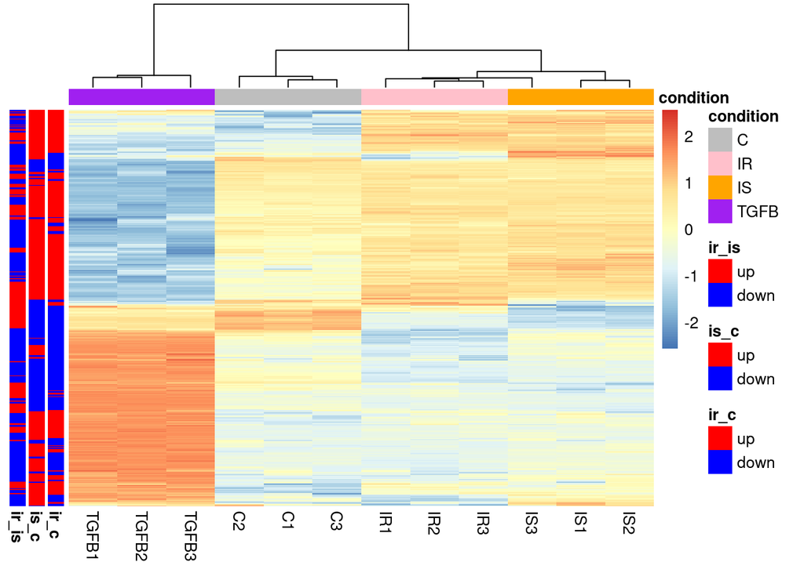

```r
pheatmap(assays(dat_flt)$rle_log2,
         annotation_col = dds_annot_col,
         annotation_row = dds_annot_row,
         annotation_colors = dds_annot_colors,
         cluster_rows=dds.hc01.row,
         cluster_cols=dds.hc01.col,
         treeheight_row = 0,
         show_rownames = FALSE,
         show_colnames = TRUE,
         scale = "row")
```

> The TGFbeta control has a strong signal. IR and IS are more similar to each other compared to the control. IR and IS differ in the upregulated genes.

## All DE Genes (No TGFB)

```r
no_tgfb_ensembl <- ensembl_sigs[!grepl("tgfb", x=names(ensembl_sigs), fixed=TRUE)]
unique_union_de_genes_notgfb <- no_tgfb_ensembl %>% unlist %>% unique
dat_flt <- dat[unique_union_de_genes_notgfb,dat$condition != "TGFB"]

dds_annot_col <- colData(dat_flt) %>% data.frame %>% dplyr::select(condition)

dds_annot_row <- data.frame(
  ir_c = dds_IR_C_res %>% as.data.frame() %>% dplyr::filter(row.names(dds_IR_C_res) %in% unique_union_de_genes_notgfb) %>%
    dplyr::transmute(ir_c=ifelse(log2FoldChange>0,"up","down")),
  is_c = dds_IS_C_res %>% as.data.frame() %>% dplyr::filter(row.names(dds_IS_C_res) %in% unique_union_de_genes_notgfb) %>%
    dplyr::transmute(is_c=ifelse(log2FoldChange>0,"up","down")),
  ir_is = dds_IR_IS_res %>% as.data.frame() %>% dplyr::filter(row.names(dds_IR_IS_res) %in% unique_union_de_genes_notgfb) %>%
    dplyr::transmute(ir_is=ifelse(log2FoldChange>0,"up","down"))
)

dds_annot_colors <- list(condition=c(C="gray",IR="pink", IS="orange"),
                     ir_c=c(up="red",down="blue"),
                     is_c=c(up="red",down="blue"),
                     ir_is=c(up="red",down="blue"))

## use Euclidean distance for columns/samples
## use ward as agglomeration rule
dds.hc01.col <- hcopt(dist(t(assays(dat_flt)$rle_log2)),method="ward.D2")

## use 1-correlation as distance for for rows/genes
## use ward as agglomeration rule
dds.hc01.row <- hcopt(as.dist(1-cor(t(assays(dat_flt)$rle_log2))),method="ward.D2")
```

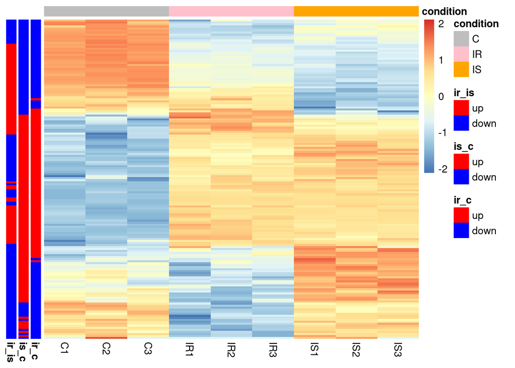

```r
pheatmap(assays(dat_flt)$rle_log2,
         annotation_col = dds_annot_col,
         annotation_row = dds_annot_row,
         annotation_colors = dds_annot_colors,
         cluster_rows=dds.hc01.row,
         treeheight_row = 0,
         #cluster_cols=dds.hc01.col,
         cluster_cols = FALSE,
         show_rownames = FALSE,
         show_colnames = TRUE,
         scale = "row")
```

## IR IS Heatmap

```r
ir_is_ensembl_sigs <- ensembl_sigs[c("ir_is_up", "ir_is_down")]
ir_is_mgi_sigs <- lapply(ir_is_ensembl_sigs, ensembl_symbol, sExp=dat)
```

```r
dat_flt <- dat[unlist(ir_is_ensembl_sigs),]
rownames(dat_flt) <- rowData(dat_flt)$mgi_symbol %>% unlist

dds_annot_col <- colData(dat_flt) %>% data.frame %>% dplyr::select(condition)

dds_annot_row <- data.frame(
  ir_is = dds_IR_IS_res %>% as.data.frame() %>% dplyr::filter(row.names(dds_IR_IS_res) %in% unlist(ir_is_ensembl_sigs)) %>%
    dplyr::transmute(ir_is=ifelse(log2FoldChange>0,"up","down"))
)
mgi_rownames <- lapply(rownames(dds_annot_row), ensembl_symbol, sExp=dat) %>% unlist
rownames(dds_annot_row) <- mgi_rownames

dds_annot_colors <- list(condition=c(C="gray",IR="pink", IS="orange", TGFB="purple"),
                     ir_c=c(up="red",down="blue"),
                     is_c=c(up="red",down="blue"),
                     ir_is=c(up="red",down="blue"))

## use Euclidean distance for columns/samples
## use ward as agglomeration rule
dds.hc01.col <- hcopt(dist(t(assays(dat_flt)$rle_log2)),method="ward.D2")

## use 1-correlation as distance for for rows/genes
## use ward as agglomeration rule
dds.hc01.row <- hcopt(as.dist(1-cor(t(assays(dat_flt)$rle_log2))),method="ward.D2")
```

```r
tiff(file=file.path(PATH, "results/ir_is_genes_heatmap.tiff"), width=7, height=7, res=1200, units="in")
pheatmap(assays(dat_flt)$rle_log2,
         annotation_col = dds_annot_col,
         annotation_row = dds_annot_row,
         annotation_colors = dds_annot_colors,
         cluster_rows=dds.hc01.row,
         cluster_cols=FALSE,
         show_rownames = TRUE,
         cellheight = 5,
         cellwidth = 15,
         treeheight_row = 5,
         treeheight_col = 5,
         fontsize_row = 4,
         show_colnames = TRUE,
         scale = "row")
dev.off()
```

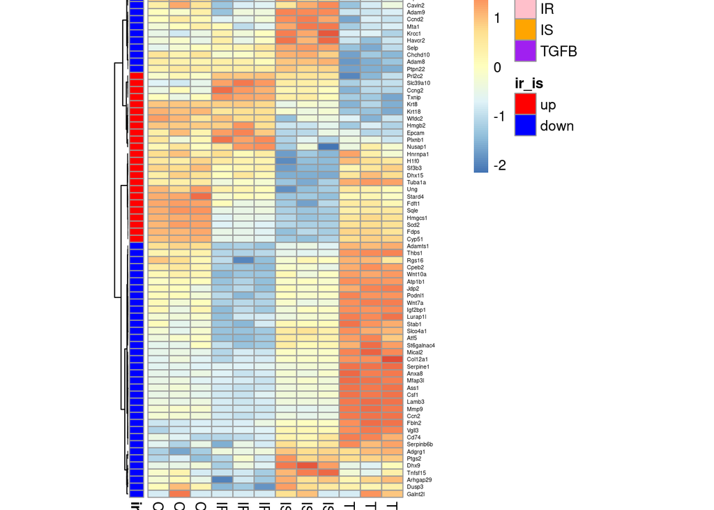

```r
pheatmap(assays(dat_flt)$rle_log2,
         annotation_col = dds_annot_col,
         annotation_row = dds_annot_row,
         annotation_colors = dds_annot_colors,
         cluster_rows=dds.hc01.row,
         cluster_cols=FALSE,
         show_rownames = TRUE,
         cellheight = 5,
         cellwidth = 15,
         treeheight_row = 5,
         treeheight_col = 5,
         fontsize_row = 4,
         show_colnames = TRUE,
         scale = "row")
```

## IR IS No TGFB

```r
dat_flt <- dat[unlist(ir_is_ensembl_sigs),dat$condition != "TGFB"]
rownames(dat_flt) <- rowData(dat_flt)$mgi_symbol %>% unlist

dds_annot_col <- colData(dat_flt) %>% data.frame %>% dplyr::select(condition)

dds_annot_row <- data.frame(
  ir_is = dds_IR_IS_res %>% as.data.frame() %>% dplyr::filter(row.names(dds_IR_IS_res) %in% unlist(ir_is_ensembl_sigs)) %>%
    dplyr::transmute(ir_is=ifelse(log2FoldChange>0,"up","down"))
)
mgi_rownames <- lapply(rownames(dds_annot_row), ensembl_symbol, sExp=dat) %>% unlist
rownames(dds_annot_row) <- mgi_rownames

dds_annot_colors <- list(condition=c(C="gray",IR="pink", IS="orange"),
                     ir_c=c(up="red",down="blue"),
                     is_c=c(up="red",down="blue"),
                     ir_is=c(up="red",down="blue"))

## use Euclidean distance for columns/samples
## use ward as agglomeration rule
dds.hc01.col <- hcopt(dist(t(assays(dat_flt)$rle_log2)),method="ward.D2")

## use 1-correlation as distance for for rows/genes
## use ward as agglomeration rule
dds.hc01.row <- hcopt(as.dist(1-cor(t(assays(dat_flt)$rle_log2))),method="ward.D2")
```

```r
tiff(file=file.path(PATH, "results/ir_is_genes_no_tgfb_heatmap.tiff"), width=7, height=7, res=1200, units="in")
pheatmap(assays(dat_flt)$rle_log2,
         annotation_col = dds_annot_col,
         annotation_row = dds_annot_row,
         annotation_colors = dds_annot_colors,
         cluster_rows=dds.hc01.row,
         cluster_cols=FALSE,
         show_rownames = TRUE,
         cellheight = 5,
         cellwidth = 15,
         treeheight_row = 5,
         treeheight_col = 5,
         fontsize_row = 4,
         show_colnames = TRUE,
         scale = "row")
dev.off()
```

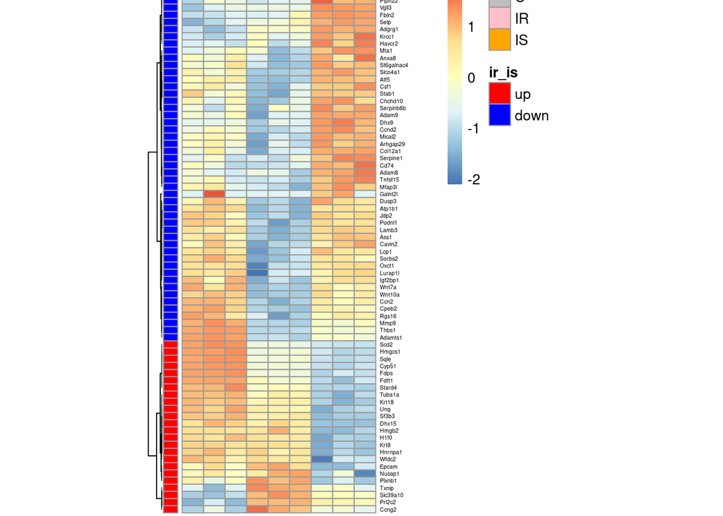

```r
pheatmap(assays(dat_flt)$rle_log2,
         annotation_col = dds_annot_col,
         annotation_row = dds_annot_row,
         annotation_colors = dds_annot_colors,
         cluster_rows=dds.hc01.row,
         cluster_cols=FALSE,
         show_rownames = TRUE,
         cellheight = 5,
         cellwidth = 15,
         treeheight_row = 5,
         treeheight_col = 5,
         fontsize_row = 4,
         show_colnames = TRUE,
         scale = "row")
```

# Saving Signatures

```r
deseq_list <- list(ir_is = dds_IR_IS_res, ir_c = dds_IR_C_res, is_c = dds_IS_C_res,
                   tgfb_is = dds_TGFB_IS_res, tgfb_c = dds_TGFB_C_res, tgfb_ir = dds_TGFB_IR_res)
saveRDS(deseq_list,file=file.path(PATH,"data/deseq_list.rds"))
saveRDS(all_sigs,file=file.path(PATH,"data/signatures_symbol.rds"))
```

# Log Fold Changes Table

```r
emt_example <- readxl::read_excel(file.path(PATH, "data/20230203EMT-CISIRTGFB-Fold Change.xlsx"))
emt_set <- emt_example$geneid
logfold_df <- data.frame(ir_is = deseq_list$ir_is$log2FoldChange,
                         ir_c = deseq_list$ir_c$log2FoldChange,
                         is_c = deseq_list$is_c$log2FoldChange,
                         tgfb_is = deseq_list$tgfb_is$log2FoldChange,
                         tgfb_c = deseq_list$tgfb_c$log2FoldChange,
                         tgfb_ir = deseq_list$tgfb_ir$log2FoldChange)
test <- lapply(deseq_list, rownames)
for(i in seq_along(test)) {
  for(j in seq_along(test)) {
    stopifnot(all.equal(test[[i]], test[[j]]))
  }
}

rownames(logfold_df) <- rownames(deseq_list$ir_is)
logfold_df <- logfold_df %>% rownames_to_column(var = "geneid")
logfold_df$genesymbol <- ensembl_symbol(logfold_df$geneid, sExp = dat)
logfold_df <- logfold_df[,sort(colnames(logfold_df))]
emt_df <- logfold_df %>% filter(genesymbol %in% emt_set)
write.csv(emt_df, file.path(PATH, "data/emt_logfold.csv"), row.names = FALSE)
```